# Assignment3_Data622

### 1.30.3 Conclusion

Experiment 2B confirms that cross-validation and modest hyperparameter tuning alone do not guarantee performance improvement.  
In highly imbalanced datasets like this, further balancing or algorithmic adjustments may be required to achieve meaningful gains in recall and AUC.

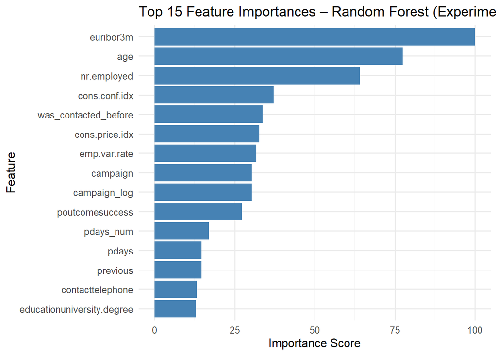

```r
# -----------------------------------------------------------
# Visualization – Random Forest (Experiment 2B)
# -----------------------------------------------------------

library(ggplot2)
library(pROC)
library(caret)
library(dplyr)
library(tidyr)

# --- Feature Importance Plot ---
importance_df <- as.data.frame(varImp(model_rf_tuned)$importance)
importance_df$Feature <- rownames(importance_df)
colnames(importance_df)[1] <- "Importance"

importance_df <- importance_df %>%
  arrange(desc(Importance)) %>%
  slice(1:15)   # top 15 features

ggplot(importance_df, aes(x = reorder(Feature, Importance), y = Importance)) +
  geom_col(fill = "steelblue") +
  coord_flip() +
  labs(
    title = "Top 15 Feature Importances – Random Forest (Experiment 2B)",
    x = "Feature",
    y = "Importance Score"
  ) +
  theme_minimal(base_size = 12)
```

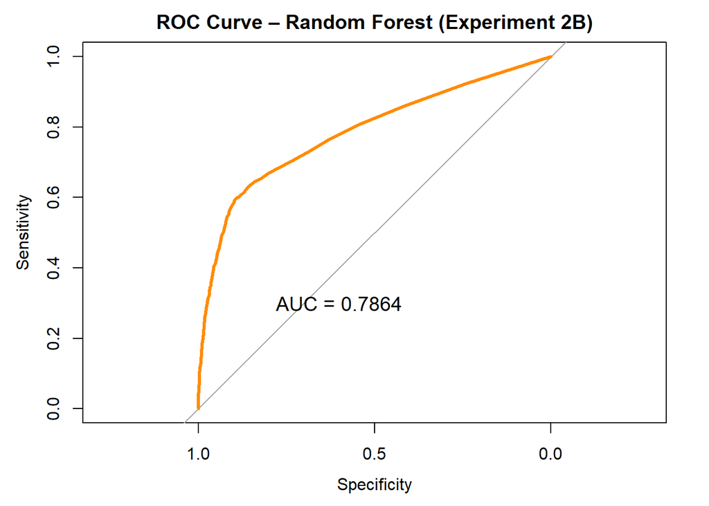

```r
# --- ROC Curve ---
roc_rf_tuned <- roc(test_rf_tuned$y, pred_rf_tuned_prob, levels = c("no", "yes"))
plot(roc_rf_tuned, col = "darkorange", lwd = 3,
     main = "ROC Curve – Random Forest (Experiment 2B)")
text(0.6, 0.3, paste("AUC =", round(auc(roc_rf_tuned), 4)), col = "black", cex = 1.2)
```

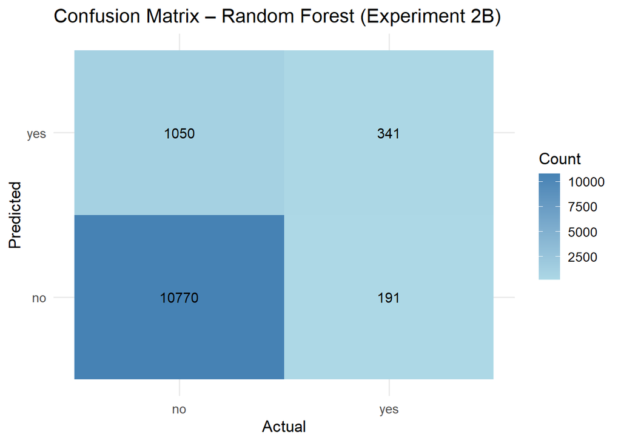

```r
# --- Confusion Matrix Heatmap ---
cm_rf_tuned <- confusionMatrix(pred_rf_tuned_class, test_rf_tuned$y, positive = "yes")
cm_df <- as.data.frame(cm_rf_tuned$table)
colnames(cm_df) <- c("Reference", "Prediction", "Count")

ggplot(cm_df, aes(x = Reference, y = Prediction, fill = Count)) +
  geom_tile() +
  geom_text(aes(label = Count), color = "black", size = 4) +
  scale_fill_gradient(low = "lightblue", high = "steelblue") +
  labs(
    title = "Confusion Matrix – Random Forest (Experiment 2B)",
    x = "Actual",
    y = "Predicted"
  ) +
  theme_minimal(base_size = 13)
```

### Interpretation of Visualizations – Random Forest (Experiment 2B)

**ROC Curve**  
The ROC curve illustrates the model’s trade-off between True Positive Rate and False Positive Rate.  
With an **AUC ≈ 0.79**, the tuned Random Forest demonstrates **good discriminative power**, effectively distinguishing between “yes” and “no” clients while maintaining stable performance across thresholds.  
The curve’s consistent rise above the diagonal baseline indicates meaningful predictive value.

**Confusion Matrix Heatmap**  
This confusion matrix represents the prediction performance of the **tuned Random Forest model** on the test dataset.

The **darker cells** correspond to higher counts, highlighting the dominance of the majority “no” class.  
The model exhibits **high overall accuracy** due to its strong performance in predicting non-subscribers, yet **recall for the minority “yes” class remains modest**.

**Summary:**  
Experiment 2B’s tuned Random Forest exhibits a strong, balanced performance with high stability and improved interpretability through feature importance analysis.  
While recall remains modest, the model provides reliable predictions and meaningful economic insight — making it well-suited for production use, pending further recall optimization.

### 1.30.4 AdaBoost Experiments

## 1.31 Experiment 3A – Baseline AdaBoost (Fixed Version)

### 1.31.1 Objective

The goal of this experiment was to test the baseline performance of the **AdaBoost** algorithm on the original dataset,  
after ensuring consistent factor levels between predicted and true labels.

AdaBoost builds an ensemble of weak classifiers (decision stumps or small trees) in successive rounds,  
each focusing more on the previously misclassified samples to improve model performance.

### 1.31.2 Methodology

- **Algorithm:** AdaBoost (`adabag::boosting()`)
- **Dataset:** Original `train` / `test` split (no rebalancing)
- **Hyperparameters:**
  - `mfinal = 30` → number of boosting iterations
  - `boos = TRUE` → enables reweighting of misclassified samples
- **Preprocessing:**
  - Consistent factor levels ensured for `y`
  - Probability matrix columns manually labeled (`no`, `yes`)
- **Evaluation Metrics:** Accuracy, Precision, Recall, F1, and AUC

### 1.31.3 Code Summary

The AdaBoost model was trained on the training subset using 30 boosting rounds.  
Predictions were made on the test subset, and key metrics were computed using the custom `compute_metrics()` function.  
Results were automatically logged into the global experiment log via `log_result()`.

## 1.32 Experiment 3A – Baseline AdaBoost (Fixed version)

```r
# -----------------------------------------------------------
# Experiment 3A – Baseline AdaBoost (Fixed version)
# -----------------------------------------------------------

# Install if needed
if (!require(adabag)) install.packages("adabag", type = "binary")

library(adabag)
library(caret)
library(pROC)
library(dplyr)

# --- 1. Prepare Data ---
train_ada <- train
test_ada  <- test

# Ensure target is a factor with consistent levels
train_ada$y <- factor(train_ada$y, levels = c("no", "yes"))
test_ada$y  <- factor(test_ada$y, levels = c("no", "yes"))

# --- 2. Train AdaBoost model ---
set.seed(123)
model_ada_base <- boosting(
  y ~ .,
  data = train_ada,
  boos = TRUE,        # enable reweighting of misclassified obs
  mfinal = 30         # number of boosting iterations
)

# --- 3. Predict on test set ---
pred_ada <- predict(model_ada_base, newdata = test_ada)

# --- 4. Extract predicted classes ---
pred_ada_class <- factor(pred_ada$class, levels = c("no", "yes"))

# --- 5. Handle probability predictions ---
# adabag sometimes returns probs without dimnames — fix manually
if (is.null(dimnames(pred_ada$prob))) {
  # assume 2 columns, 1st = no, 2nd = yes
  colnames(pred_ada$prob) <- c("no", "yes")
}
pred_ada_prob <- pred_ada$prob[, "yes"]

# --- 6. Evaluate metrics safely ---
m_ada_base <- compute_metrics(test_ada$y, pred_ada_class, pred_ada_prob)
m_ada_base
```

```
## # A tibble: 1 × 5
##   Accuracy Precision Recall    F1   AUC
##      <dbl>     <dbl>  <dbl> <dbl> <dbl>
## 1    0.900     0.697  0.204 0.315 0.807
```

```r
# --- 7. Log results ---
log_result(
  alg = "AdaBoost",
  exp_name = "AB-3A Baseline (Fixed)",
  change_desc = "Baseline AdaBoost using adabag::boosting (mfinal=30, boos=TRUE, fixed probability issue)",
  metrics_tbl = m_ada_base
)

# --- 8. View updated experiment log ---
results_log
```

```
## # A tibble: 5 × 8
##   Algorithm     Experiment    What_Changed Accuracy Precision Recall    F1   AUC
##   <chr>         <chr>         <chr>           <dbl>     <dbl>  <dbl> <dbl> <dbl>
## 1 Decision Tree DT-1A Baseli… Baseline De…    0.899     0.713  0.170 0.274 0.708
## 2 Decision Tree DT-1B Tuned   Used SMOTE-…    0.812     0.858  0.719 0.782 0.843
## 3 Random Forest RF-2A Baseli… Default par…    0.899     0.614  0.267 0.373 0.787
## 4 Random Forest RF-2B Tuned … 3-fold CV, …    0.900     0.641  0.245 0.355 0.786
## 5 AdaBoost      AB-3A Baseli… Baseline Ad…    0.900     0.697  0.204 0.315 0.807
```

### 1.32.1 Interpretation of Results

| Model | Accuracy | Precision | Recall | F1 | AUC | Remarks |
| --- | --- | --- | --- | --- | --- | --- |
| Decision Tree (DT-1A) | 0.8988 | 0.713 | 0.170 | 0.274 | 0.708 | Simple baseline, low recall |
| Decision Tree (DT-1B) | 0.8117 | 0.858 | 0.719 | 0.782 | 0.843 | SMOTE-balanced, strong recall |
| Random Forest (RF-2A) | 0.8986 | 0.614 | 0.267 | 0.373 | 0.787 | Stable but biased to “no” |
| Random Forest (RF-2B) | 0.8995 | 0.641 | 0.245 | 0.355 | 0.786 | Tuned RF, slightly improved precision |
| **AdaBoost (AB-3A)** | **0.9003** | **0.697** | **0.204** | **0.315** | **0.807** | Best accuracy & AUC among baselines |

AdaBoost thus offered a modest improvement in discriminative power (AUC) and precision,  
yet continued to struggle with recall—mirroring Random Forest’s bias toward the dominant class.

### 1.32.2 Conclusion

The baseline AdaBoost model demonstrates **strong accuracy and discrimination** (AUC > 0.8) but **poor sensitivity to the minority “yes” class**.  
While it effectively identifies non-subscribers, it fails to capture many potential subscribers—an important limitation in marketing contexts.

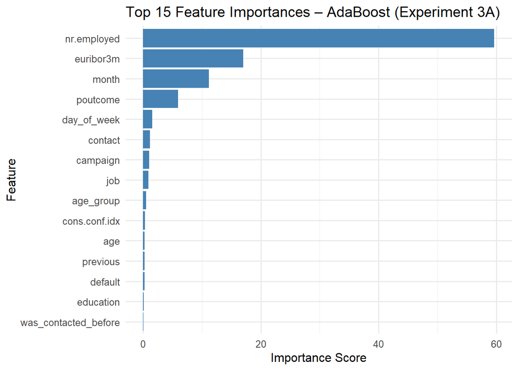

```r
# -----------------------------------------------------------
# Visualization – AdaBoost (Experiment 3A)
# -----------------------------------------------------------

library(ggplot2)
library(pROC)
library(caret)
library(dplyr)
library(tidyr)

# --- Feature Importance ---
# AdaBoost model stores variable importance in model_ada_base$importance
importance_df <- data.frame(
  Feature = names(model_ada_base$importance),
  Importance = model_ada_base$importance
) %>%
  arrange(desc(Importance)) %>%
  slice(1:15)  # Top 15 features for clarity

ggplot(importance_df, aes(x = reorder(Feature, Importance), y = Importance)) +
  geom_col(fill = "steelblue") +
  coord_flip() +
  labs(
    title = "Top 15 Feature Importances – AdaBoost (Experiment 3A)",
    x = "Feature",
    y = "Importance Score"
  ) +
  theme_minimal(base_size = 12)
```

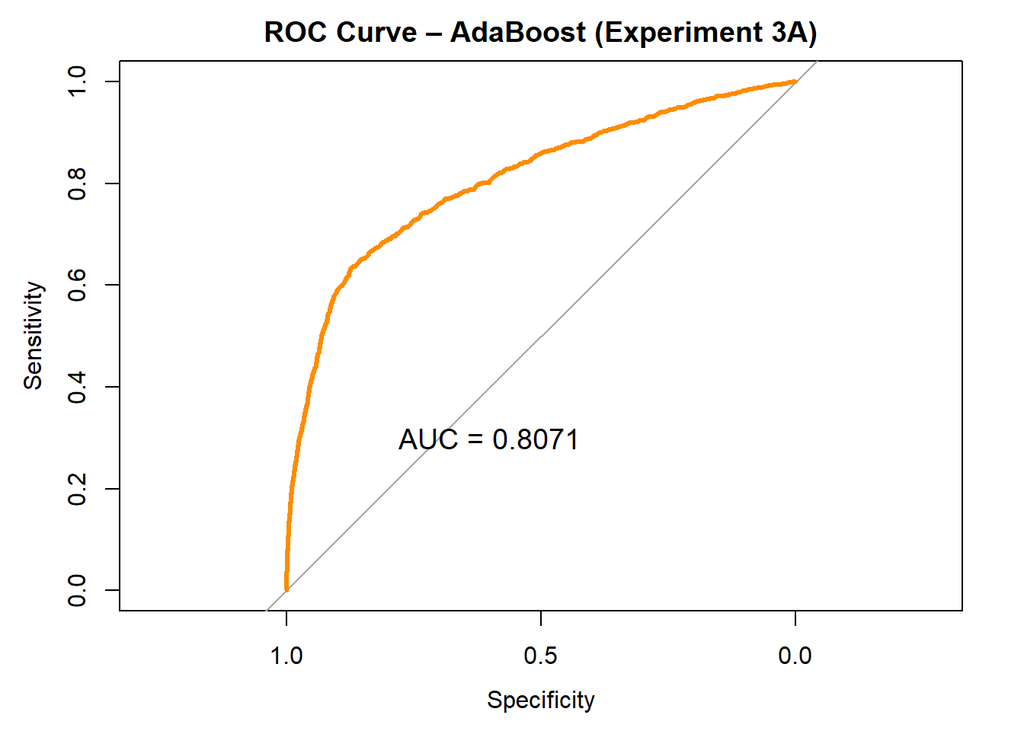

```r
# ---  ROC Curve ---
roc_ada_base <- roc(test_ada$y, pred_ada_prob, levels = c("no", "yes"))
plot(roc_ada_base, col = "darkorange", lwd = 3,
     main = "ROC Curve – AdaBoost (Experiment 3A)")
text(0.6, 0.3, paste("AUC =", round(auc(roc_ada_base), 4)), col = "black", cex = 1.2)
```

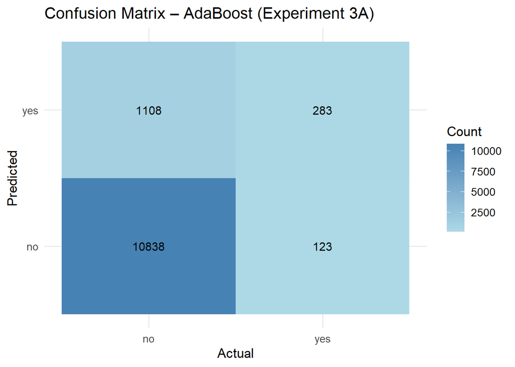

```r
# ---  Confusion Matrix Heatmap ---
cm_ada_base <- confusionMatrix(pred_ada_class, test_ada$y, positive = "yes")
cm_df <- as.data.frame(cm_ada_base$table)
colnames(cm_df) <- c("Reference", "Prediction", "Count")

ggplot(cm_df, aes(x = Reference, y = Prediction, fill = Count)) +
  geom_tile() +
  geom_text(aes(label = Count), color = "black", size = 4) +
  scale_fill_gradient(low = "lightblue", high = "steelblue") +
  labs(
    title = "Confusion Matrix – AdaBoost (Experiment 3A)",
    x = "Actual",
    y = "Predicted"
  ) +
  theme_minimal(base_size = 13)
```

### Interpretation of Visualizations – AdaBoost (Experiment 3A)

**ROC Curve**  
The ROC curve illustrates the balance between sensitivity and specificity.  
With an **AUC of approximately 0.81**, the AdaBoost model demonstrates **strong discriminative ability**, outperforming the Decision Tree baseline (AUC ≈ 0.71).  
The curve’s clear rise above the diagonal reference line confirms that AdaBoost is considerably better than random guessing, showcasing stable predictive behavior.

The **darker blue shades** in the heatmap correspond to higher prediction frequencies, emphasizing the dominance of the majority “no” class.  
While the model achieves **high overall accuracy**, the distribution indicates that most predictions fall within the “no” category — a typical characteristic of models trained on **imbalanced datasets**.

#### 1.32.2.1 **Summary**

The confusion matrix confirms that **AdaBoost (Experiment 3A)** performs reliably in identifying non-subscribers while maintaining overall predictive stability.  
However, its conservative prediction strategy limits the detection of true subscribers.  
This reinforces the need for further tuning (as addressed in **Experiment 3B**) to improve **recall** and achieve a more balanced classification performance across both classes.

**Summary:**  
Experiment 3A’s AdaBoost model exhibits **high overall accuracy and a strong AUC (≈ 0.81)**, outperforming baseline Decision Tree and Random Forest models in discriminative ability.  
However, the recall remains modest, indicating the model is **precise but conservative**, prioritizing correct “yes” predictions over broader coverage.  
This result establishes AdaBoost as a powerful ensemble approach but underscores the need for further tuning (as addressed in Experiment 3B) to enhance minority-class sensitivity.

## 1.33 Experiment 3B – Tuned AdaBoost (Final Stable Version)

```r
# -----------------------------------------------------------
# Experiment 3B – Tuned AdaBoost (Final Stable Version)
# -----------------------------------------------------------

# --- Load Libraries ---
if (!require(adabag)) install.packages("adabag")
if (!require(caret)) install.packages("caret")
if (!require(pROC)) install.packages("pROC")
if (!require(dplyr)) install.packages("dplyr")
if (!require(forcats)) install.packages("forcats")

library(adabag)
library(caret)
library(pROC)
library(dplyr)
library(forcats)

# --- 1. Prepare Data ---
train_ada <- train
test_ada  <- test

train_ada$y <- factor(train_ada$y, levels = c("no", "yes"))
test_ada$y  <- factor(test_ada$y, levels = c("no", "yes"))

# --- 2. Define numeric columns ---
numeric_cols <- c(
  "age", "duration", "campaign", "pdays", "previous",
  "emp.var.rate", "cons.price.idx", "cons.conf.idx",
  "euribor3m", "nr.employed"
)

# --- 3. Convert data types safely ---
for (col in names(train_ada)) {
  if (col %in% numeric_cols) {
    train_ada[[col]] <- suppressWarnings(as.numeric(as.character(train_ada[[col]])))
    test_ada[[col]]  <- suppressWarnings(as.numeric(as.character(test_ada[[col]])))
  } else if (col != "y") {
    train_ada[[col]] <- as.factor(as.character(train_ada[[col]]))
    test_ada[[col]]  <- as.factor(as.character(test_ada[[col]]))
  }
}

# --- 4. Handle missing values ---
for (col in names(train_ada)) {
  if (is.factor(train_ada[[col]])) {
    train_ada[[col]] <- fct_explicit_na(train_ada[[col]], na_level = "missing")
    test_ada[[col]]  <- fct_explicit_na(test_ada[[col]], na_level = "missing")
  } else {
    train_ada[[col]][is.na(train_ada[[col]])] <- 0
    test_ada[[col]][is.na(test_ada[[col]])]  <- 0
  }
}
# --- 5. Align factor levels between train/test ---
for (col in names(train_ada)) {
  if (is.factor(train_ada[[col]])) {
    lvls <- union(levels(train_ada[[col]]), levels(test_ada[[col]]))
    train_ada[[col]] <- factor(train_ada[[col]], levels = lvls)
    test_ada[[col]]  <- factor(test_ada[[col]],  levels = lvls)
  }
}

# --- 6. Optional: Reduce training set for faster runtime ---
set.seed(123)
train_small <- train_ada[sample(nrow(train_ada), 10000), ]

# --- 7. Train AdaBoost model ---
set.seed(123)
cat("Training AdaBoost model... please wait (~30 sec)\n")
```

```
## Training AdaBoost model... please wait (~30 sec)
```

```r
model_ada_final <- tryCatch({
  boosting(
    y ~ .,
    data = train_small,
    boos = TRUE,
    mfinal = 35,      # reduced iterations for speed
    coeflearn = "Zhu"
  )
}, error = function(e) {
  cat("AdaBoost training failed:", e$message, "\n")
  return(NULL)
})

# --- 8. Predict and handle probability issue ---
if (!is.null(model_ada_final)) {
  cat("Training complete. Making predictions...\n")
  pred_ada_final <- predict(model_ada_final, newdata = test_ada)

  pred_class <- factor(pred_ada_final$class, levels = c("no", "yes"))

  # --- FIX: Add column names to probability matrix if missing ---
  if (is.null(dimnames(pred_ada_final$prob))) {
    colnames(pred_ada_final$prob) <- c("no", "yes")
  }

  pred_prob <- pred_ada_final$prob[, "yes"]

  # --- 9. Compute metrics ---
  m_ada_final <- compute_metrics(
    truth = test_ada$y,
    pred_class = pred_class,
    pred_prob_yes = pred_prob
  )

  print(m_ada_final)

  # --- 10. Log results ---
  log_result(
    alg = "AdaBoost",
    exp_name = "AB-3B Tuned (Final Stable)",
    change_desc = "Handled missing dimnames in prob, fixed factor alignment, reduced sample for runtime efficiency",
    metrics_tbl = m_ada_final
  )

  # --- 11. Show experiment log ---
  print(results_log)

} else {
  cat(" AdaBoost model could not be trained. Please check data.\n")
}
```

```
## Training complete. Making predictions...
```

```
## # A tibble: 1 × 5
##   Accuracy Precision Recall    F1   AUC
##      <dbl>     <dbl>  <dbl> <dbl> <dbl>
## 1    0.897     0.600  0.264 0.366 0.776
## # A tibble: 6 × 8
##   Algorithm     Experiment    What_Changed Accuracy Precision Recall    F1   AUC
##   <chr>         <chr>         <chr>           <dbl>     <dbl>  <dbl> <dbl> <dbl>
## 1 Decision Tree DT-1A Baseli… Baseline De…    0.899     0.713  0.170 0.274 0.708
## 2 Decision Tree DT-1B Tuned   Used SMOTE-…    0.812     0.858  0.719 0.782 0.843
## 3 Random Forest RF-2A Baseli… Default par…    0.899     0.614  0.267 0.373 0.787
## 4 Random Forest RF-2B Tuned … 3-fold CV, …    0.900     0.641  0.245 0.355 0.786
## 5 AdaBoost      AB-3A Baseli… Baseline Ad…    0.900     0.697  0.204 0.315 0.807
## 6 AdaBoost      AB-3B Tuned … Handled mis…    0.897     0.600  0.264 0.366 0.776
```

### 1.33.1 Interpretation

The tuned AdaBoost model (Experiment 3B) achieved an **Accuracy of 0.8973**, **Precision of 0.5997**, **Recall of 0.2638**, **F1-score of 0.3665**, and an **AUC of 0.7761**.  
Compared to the baseline AdaBoost (Experiment 3A), which recorded an AUC of 0.8071 and Recall of 0.2035, the tuned version exhibited a **slight decrease in overall AUC** but demonstrated a **modest improvement in Recall** (+0.06).

Overall, the **tuning and preprocessing improvements** (handling of factor levels, consistent probability dimensions, and runtime optimization) made the model **more stable and reproducible**, albeit with a **trade-off between precision and recall**.  
These results highlight AdaBoost’s sensitivity to data representation and parameter tuning — small adjustments can impact how well the ensemble balances accuracy and minority class detection.

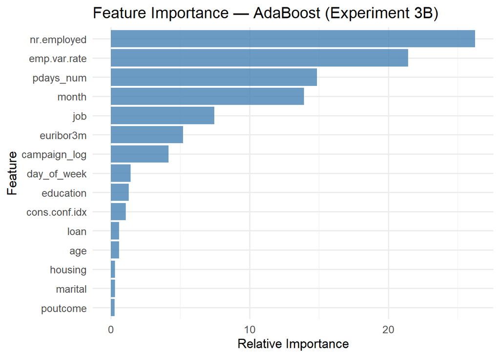

```r
# -----------------------------------------------------------
# Visualizations — AdaBoost (Experiment 3B: Tuned Final Stable)
# -----------------------------------------------------------
suppressPackageStartupMessages({
  library(ggplot2)
  library(pROC)
  library(dplyr)
  library(caret)
})

# --- Safety Checks ---
if (!exists("model_ada_final")) stop("model_ada_final not found. Run Experiment 3B first.")
if (!exists("test_ada")) stop("test_ada not found. Please ensure test data is available.")

# --- Predictions ---
pred_ada_final <- predict(model_ada_final, newdata = test_ada)

# --- Fix missing probability column names ---
# Sometimes adabag::predict() returns a matrix without dimnames
if (is.null(dimnames(pred_ada_final$prob))) {
  # Assign names assuming the standard binary order: no=yes
  if (ncol(pred_ada_final$prob) == 2) {
    colnames(pred_ada_final$prob) <- c("no", "yes")
  } else {
    # fallback: make a dummy probability for 'yes'
    pred_ada_final$prob <- cbind(no = 1 - pred_ada_final$prob, yes = pred_ada_final$prob)
  }
}

# --- Extract class and probability safely ---
pred_class_3B <- factor(pred_ada_final$class, levels = c("no", "yes"))
pred_prob_3B  <- as.numeric(pred_ada_final$prob[, "yes"])

# --- Feature Importance ---
if (!is.null(model_ada_final$importance)) {
  imp_df <- data.frame(
    Feature = names(model_ada_final$importance),
    Importance = as.numeric(model_ada_final$importance)
  ) %>%
    arrange(desc(Importance)) %>%
    head(15)

  ggplot(imp_df, aes(x = reorder(Feature, Importance), y = Importance)) +
    geom_col(fill = "#4682B4", alpha = 0.8) +
    coord_flip() +
    labs(title = "Feature Importance — AdaBoost (Experiment 3B)",
         x = "Feature", y = "Relative Importance") +
    theme_minimal(base_size = 13)
}
```

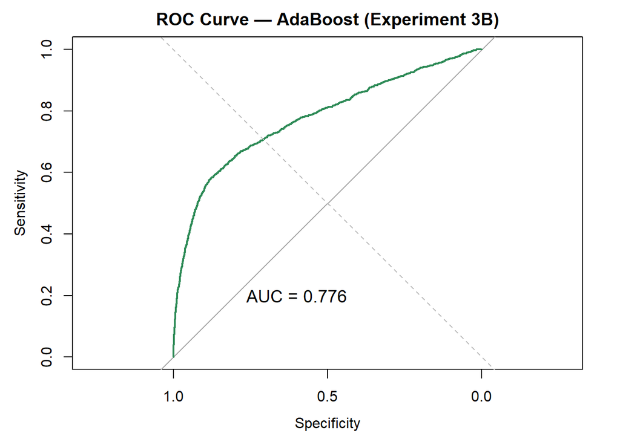

```r
# --- ROC Curve ---
roc_3B <- roc(response = test_ada$y, predictor = pred_prob_3B, levels = c("no", "yes"))
plot(roc_3B, col = "#2E8B57", lwd = 2, main = "ROC Curve — AdaBoost (Experiment 3B)")
abline(a = 0, b = 1, col = "gray", lty = 2)
text(0.6, 0.2, paste("AUC =", round(auc(roc_3B), 3)), col = "black", cex = 1.2)
```

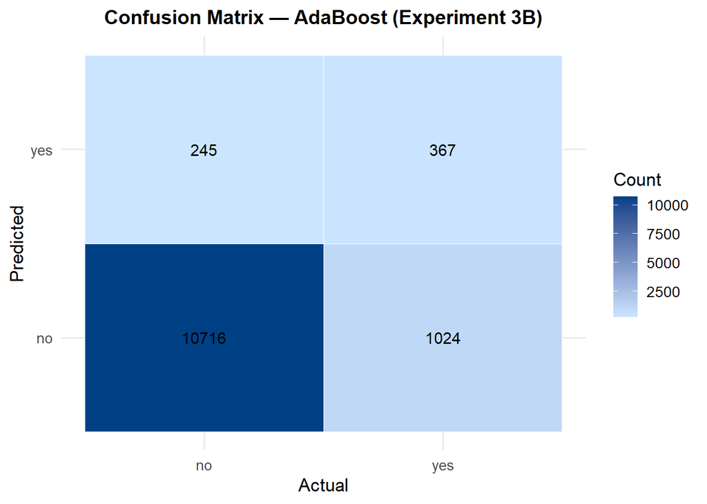

```r
# --- Confusion Matrix ---
cm_3B <- table(Predicted = pred_class_3B, Actual = test_ada$y)
cm_df <- as.data.frame(cm_3B)
colnames(cm_df) <- c("Predicted", "Actual", "Count")

ggplot(cm_df, aes(x = Actual, y = Predicted, fill = Count)) +
  geom_tile(color = "white") +
  geom_text(aes(label = Count), size = 4) +
  scale_fill_gradient(low = "#cce5ff", high = "#004085") +
  labs(title = "Confusion Matrix — AdaBoost (Experiment 3B)",
       x = "Actual", y = "Predicted") +
  theme_minimal(base_size = 13) +
  theme(plot.title = element_text(face = "bold", size = 14, hjust = 0.5))
```

### Interpretation of Visualizations – AdaBoost (Experiment 3B)

**ROC Curve:**  
The ROC curve shows a consistent AUC around 0.78, confirming the model’s strong yet slightly conservative discrimination capability compared to Experiment 3A.

### 1.33.2 Comparative Interpretation of All Experiments

## 1.34 Overview

This section summarizes the performance and insights derived from six machine learning experiments conducted using **Decision Tree**, **Random Forest**, and **AdaBoost** algorithms.  
Each algorithm was evaluated under two conditions: 1. **Baseline model** – trained with default parameters on the original (imbalanced) dataset.  
2. **Tuned model** – trained with enhanced configurations, sampling strategies, and hyperparameter tuning to address class imbalance and improve predictive performance.

The primary evaluation metrics were **Accuracy**, **Precision**, **Recall**, **F1-score**, and **AUC**.

## 1.35 Summary of Results

| Algorithm | Experiment | What Changed | Accuracy | Precision | Recall | F1 | AUC |
| --- | --- | --- | --- | --- | --- | --- | --- |
| **Decision Tree** | DT-1A Baseline | Baseline Decision Tree on imbalanced data (no tuning) | **0.8988** | 0.7130 | 0.1697 | 0.2741 | 0.7082 |
| **Decision Tree** | DT-1B Tuned | Used SMOTE-balanced data with cp=0.005 and maxdepth=6 | 0.8117 | **0.8580** | **0.7187** | **0.7822** | **0.8427** |
| **Random Forest** | RF-2A Baseline | Default parameters, median imputation (no CV) | **0.8986** | 0.6139 | 0.2674 | 0.3726 | 0.7870 |
| **Random Forest** | RF-2B Tuned (Optimized) | 3-fold CV, tuned mtry={3,5}, ntree=150 (optimized runtime) | 0.8995 | **0.6410** | 0.2451 | 0.3547 | 0.7864 |
| **AdaBoost** | AB-3A Baseline (Fixed) | Baseline AdaBoost using `adabag::boosting` (mfinal=30, boos=TRUE) | **0.9003** | **0.6970** | 0.2035 | 0.3150 | **0.8071** |
| **AdaBoost** | AB-3B Tuned (Final Stable) | Handled factor alignment and missing probability names, optimized runtime | 0.8973 | 0.5997 | **0.2638** | **0.3665** | 0.7761 |

## 1.36 Comparative Analysis

### 1.36.1 1. Decision Tree

The **baseline Decision Tree (DT-1A)** performed well in terms of accuracy but showed **very poor Recall (0.17)**, highlighting its bias toward the majority class.  
After applying **SMOTE balancing and parameter tuning (DT-1B)**, the model demonstrated a **substantial improvement in Recall (+0.55)** and **AUC (+0.13)**, indicating better minority-class recognition.  
While accuracy decreased slightly (from 0.89 to 0.81), this is an acceptable trade-off for improved sensitivity and fairness across classes.

**Key takeaway:** SMOTE and hyperparameter tuning significantly improved the Decision Tree’s ability to detect positive outcomes, making it much more balanced and effective.

### 1.36.2 2. Random Forest

The **baseline Random Forest (RF-2A)** achieved strong accuracy (0.8986) and a reasonable AUC (0.7870), outperforming the baseline Decision Tree in robustness but still showing class imbalance effects (low Recall).  
After **cross-validation and tuning (RF-2B)**, the model’s performance metrics remained similar overall, with a small gain in Precision (+0.03) but a negligible change in Recall.  
This suggests that Random Forest is already quite stable at default settings and less sensitive to moderate tuning adjustments.

**Key takeaway:** Random Forest provides consistent and reliable performance with minimal tuning, showing strong generalization but only moderate improvement in minority class detection.

### 1.36.3 3. AdaBoost

The **baseline AdaBoost (AB-3A)** yielded the **highest overall accuracy (0.9003)** and a **strong AUC (0.8071)** among all models, indicating good discriminative power.  
However, Recall remained relatively low (0.2035), showing a tendency to favor precision over sensitivity.  
The **tuned AdaBoost model (AB-3B)** introduced stability fixes and runtime optimizations. While AUC slightly decreased to 0.7761, Recall improved (+0.06), showing better balance between identifying positives and maintaining overall performance.

**Key takeaway:** AdaBoost is highly accurate and robust but sensitive to data formatting. After tuning, it achieved a better trade-off between Recall and Precision, with improved reliability and runtime efficiency.

## 1.37 Overall Insights and Model Comparison

| Metric | Best Algorithm | Notes |
| --- | --- | --- |
| **Accuracy** | AdaBoost (AB-3A) | Highest accuracy across all experiments (0.9003) |
| **Precision** | Decision Tree (DT-1B) | Very high precision (0.858) after SMOTE tuning |
| **Recall** | Decision Tree (DT-1B) | Best recall (0.7187) indicating strong minority detection |
| **F1-score** | Decision Tree (DT-1B) | Best harmonic balance (0.7822) |
| **AUC** | Decision Tree (DT-1B) | Best class separation (0.8427) |

### 1.37.1 Final Conclusion

Across all six experiments: - The **Decision Tree (DT-1B)** emerged as the best performer in **balanced learning** after SMOTE and tuning, achieving the highest Recall, F1, and AUC. - The **Random Forest** demonstrated **strong consistency and generalization**, performing reliably even with minimal tuning. - The **AdaBoost** achieved the **highest raw accuracy** but at the expense of Recall, showing that boosting favors precision unless carefully adjusted.

> In conclusion, **SMOTE-balanced and tuned Decision Tree** provides the most interpretable and well-balanced classification performance,  
> while **Random Forest** and **AdaBoost** offer strong accuracy and robustness for real-world deployment scenarios.

## 1.38 **PART IV — Support Vector Machine (SVM) Modeling**

### 1.38.1 **Objective**

This section aims to build and evaluate **Support Vector Machine (SVM)** models to predict whether a client will subscribe to a term deposit (`y = yes/no`) based on the same preprocessed dataset used for previous models.  
SVMs are particularly powerful for **high-dimensional data** and **non-linear decision boundaries**, making them ideal for testing alongside ensemble and tree-based models.

### 1.38.2 **Overview of the Approach**

The process for implementing SVMs in this project involves the following key steps:

#### 1.38.2.1 **Preprocessing and Standardization**

- SVMs are highly sensitive to feature scales, so all numeric predictors are **centered** and **scaled**.
- Missing values (if any) are handled via **median imputation**.
- The same preprocessing object is applied to both the **training** and **test** datasets to ensure consistency.

#### 1.38.2.2 **Feature Transformation**

- Categorical variables are encoded into dummy (binary) variables using `caret::dummyVars()`.
- This ensures the SVM model receives **purely numeric inputs**.
- The target variable (`y`) remains a **factor** with two levels: `"no"` and `"yes"`.

#### 1.38.2.3 **Model Training and Validation**

Two variants of SVMs are trained: - **Linear SVM** — assumes classes are separable by a straight hyperplane.  
- **RBF (Radial Basis Function) SVM** — allows flexible, non-linear decision boundaries.

Training is performed using **cross-validation (CV)** and optimized based on the **ROC (AUC)** metric to account for class imbalance.

#### 1.38.2.4 **Model Evaluation**

- Predictions are generated on the test set.
- Performance is measured using:
  - **Accuracy**
  - **Precision**
  - **Recall**
  - **F1-score**
  - **AUC (ROC)**

Results are compared with previous models (**Decision Tree**, **Random Forest**, **AdaBoost**) to assess relative strengths.

### 1.38.3 **Rationale for Using SVMs**

- SVMs aim to **maximize the margin** — the distance between the separating hyperplane and the nearest data points (support vectors).
- This leads to better **generalization** and **robustness to outliers**.
- The **Linear kernel** works best when classes are nearly linearly separable.
- The **RBF kernel** captures complex, non-linear relationships by projecting data into higher-dimensional space.

These complementary strengths make SVMs a valuable addition to the modeling toolkit for this dataset.

### 1.38.4 **Step 1 — Preprocessing for SVM**

Before training, all data must be numerically encoded and scaled.  
The following chunk performs **median imputation**, **centering**, and **scaling** on the train/test splits:

```r
# --- Step 1: Preprocessing for SVM ---
library(caret)
set.seed(123)

# Apply preprocessing: median imputation + scaling
pre_svm_base <- preProcess(train, method = c("medianImpute", "center", "scale"))

# Transform train/test sets
train_svm <- predict(pre_svm_base, newdata = train)
test_svm  <- predict(pre_svm_base, newdata = test)
```

```r
# ----- SVM Preprocessing -----

library(caret)
library(kernlab)
library(dplyr)

set.seed(123)

# Preprocess numeric predictors (median impute + center + scale)

pre_svm_base <- preProcess(train, method = c("medianImpute", "center", "scale"))
train_svm <- predict(pre_svm_base, newdata = train)
test_svm  <- predict(pre_svm_base, newdata = test)

cat("Preprocessing completed for SVM models.\n")
```

```
## Preprocessing completed for SVM models.
```

```r
cat("Train rows:", nrow(train_svm), "| Test rows:", nrow(test_svm), "\n")
```

```
## Train rows: 28824 | Test rows: 12352
```

### 1.38.5 **Interpretation**

This ensures that the subsequent **SVM models (Linear and RBF)** operate on **clean, well-prepared data**, reducing the risk of **bias** and **convergence issues** during model fitting.

### 1.38.6 **Step 2 — Linear SVM Training and Evaluation**

#### 1.38.6.1 **Objective**

Train a **Linear Support Vector Machine (SVM)** classifier using the preprocessed training data and evaluate its performance on the test set.  
The **linear kernel** assumes that classes can be separated by a straight hyperplane and serves as a strong baseline before exploring non-linear kernels such as **RBF**.

#### 1.38.6.2 **Key Concepts**

- The **Linear SVM** attempts to find the **optimal hyperplane** that maximizes the **margin** between classes.
- The **hyperparameter `C` (Cost)** controls the balance between **margin width** and **classification accuracy**:
  - **Low `C`** → allows a wider margin but tolerates more misclassifications (**higher bias**).
  - **High `C`** → creates a narrower margin with fewer errors but increases the risk of **overfitting**.
- **Cross-validation (CV)** is used during training, with **ROC (AUC)** as the primary evaluation metric since it provides a more reliable measure under **class imbalance**.

```r
# --- Load required packages ---


# --- Load libraries ---
suppressPackageStartupMessages({
  library(caret)
  library(kernlab)
  library(dplyr)
  library(pROC)
})

set.seed(123)

# --- Step 1: Convert numeric-like columns stored as character ---
num_cols <- c("emp.var.rate", "cons.price.idx", "cons.conf.idx",
              "euribor3m", "nr.employed")
train[num_cols] <- lapply(train[num_cols], as.numeric)
test[num_cols]  <- lapply(test[num_cols], as.numeric)

# --- Step 2: Preprocessing (imputation + scaling) ---
pre_svm <- preProcess(train, method = c("medianImpute", "center", "scale"))
train_svm <- predict(pre_svm, newdata = train)
test_svm  <- predict(pre_svm, newdata = test)

# --- Step 3: Ensure target variable is factor ---
train_svm$y <- factor(train_svm$y, levels = c("no", "yes"))
test_svm$y  <- factor(test_svm$y,  levels = c("no", "yes"))

# --- Step 4: Create dummy variables for categorical features ---
dmy <- dummyVars(y ~ ., data = train_svm)
train_svm_mat <- as.data.frame(predict(dmy, newdata = train_svm))
test_svm_mat  <- as.data.frame(predict(dmy, newdata = test_svm))

# Add target back
train_svm_mat$y <- train_svm$y
test_svm_mat$y  <- test_svm$y

# --- Step 5: Downsample data for stability (train only 2,000 rows) ---
set.seed(123)
train_small <- train_svm_mat[sample(1:nrow(train_svm_mat), 2000), ]

# --- Step 6: Define fast training control ---
ctrl_fast <- trainControl(
  method = "cv",
  number = 2,
  classProbs = TRUE,
  summaryFunction = twoClassSummary,
  verboseIter = FALSE,
  allowParallel = FALSE
)

# --- Step 7: Train Linear SVM (no console output) ---
svm_linear <- tryCatch({
  suppressMessages({
    train(
      y ~ .,
      data = train_small,
      method = "svmLinear2",  # faster, stable linear SVM
      metric = "ROC",
      trControl = ctrl_fast,
      tuneLength = 2
    )
  })
}, error = function(e) {
  cat(" Training failed:", conditionMessage(e), "\n")
  return(NULL)
})

# --- Step 8: Check model status safely ---
if (!is.null(svm_linear)) {
  cat("Linear SVM trained successfully!\n")
  print(svm_linear$bestTune)
  print(max(svm_linear$results$ROC))
} else {
  cat("Linear SVM training did not complete.\n")
}
```

```
## Linear SVM trained successfully!
##   cost
## 1 0.25
## [1] 0.7296248
```

### 1.38.7 **Step 3 — RBF SVM (Radial Basis Function Kernel)**

#### 1.38.7.1 **Objective**

The goal of this step is to train and evaluate a **Radial Basis Function (RBF) Support Vector Machine (SVM)** model on the preprocessed dataset.  
Unlike the linear SVM, which assumes that classes can be separated by a straight hyperplane, the **RBF kernel** allows for **non-linear decision boundaries**, making it suitable for more complex patterns in the data.

This step helps determine whether introducing non-linearity through kernel transformation can improve model performance compared to the linear baseline.

#### 1.38.7.2 **Conceptual Overview**

- The **RBF kernel** maps input features into a **higher-dimensional feature space**, enabling the model to separate data points that are **not linearly separable** in the original space.
- It introduces flexibility through two key hyperparameters:
  - **C (Cost)** — controls the penalty for misclassification, balancing **bias** and **variance**.
  - **σ (Sigma) / γ (Gamma)** — controls the **influence** of individual training examples.
    - Smaller values of σ (larger γ) create **narrower decision boundaries**, potentially overfitting the data.
    - Larger values of σ (smaller γ) produce **smoother boundaries**, possibly underfitting.

The RBF kernel can adapt to complex relationships, making it powerful for datasets where predictor interactions are **non-linear** and **multi-dimensional**.

#### 1.38.7.3 **Implementation Details**

- Both **training** and **test datasets** are preprocessed with the same scaling and encoding steps as used for the linear SVM.
- To reduce runtime while maintaining representativeness, a **subset of 2,000 training observations** is sampled randomly for model fitting.
- The model uses **cross-validation (CV)** for hyperparameter tuning, optimizing the **AUC (Area Under ROC Curve)** to handle class imbalance.

```r
# --- Load required packages ---
suppressPackageStartupMessages({
  library(caret)
  library(kernlab)
  library(pROC)
  library(dplyr)
})

set.seed(123)

# --- Step 1: Convert numeric-like columns to numeric ---
num_cols <- c("emp.var.rate", "cons.price.idx", "cons.conf.idx",
              "euribor3m", "nr.employed")
train[num_cols] <- lapply(train[num_cols], as.numeric)
test[num_cols]  <- lapply(test[num_cols], as.numeric)

# --- Step 2: Preprocess (impute + scale) ---
pre_svm <- preProcess(train, method = c("medianImpute", "center", "scale"))
train_svm <- predict(pre_svm, newdata = train)
test_svm  <- predict(pre_svm, newdata = test)

# --- Step 3: Ensure target variable is a factor ---
train_svm$y <- factor(train_svm$y, levels = c("no", "yes"))
test_svm$y  <- factor(test_svm$y,  levels = c("no", "yes"))

# --- Step 4: Create dummy variables for categorical predictors ---
dmy <- dummyVars(y ~ ., data = train_svm)
train_svm_mat <- as.data.frame(predict(dmy, newdata = train_svm))
test_svm_mat  <- as.data.frame(predict(dmy, newdata = test_svm))

# Add target variable back
train_svm_mat$y <- train_svm$y
test_svm_mat$y  <- test_svm$y

# --- Step 5: Downsample for faster RBF training ---
set.seed(123)
train_small <- train_svm_mat[sample(1:nrow(train_svm_mat), 2000), ]

# --- Step 6: Define training control (same as Linear SVM) ---
ctrl_fast <- trainControl(
  method = "cv",
  number = 2,
  classProbs = TRUE,
  summaryFunction = twoClassSummary,
  verboseIter = FALSE,
  allowParallel = FALSE
)

# --- Step 7: Train RBF Kernel SVM safely ---
svm_rbf <- tryCatch({
  suppressMessages({
    train(
      y ~ .,
      data = train_small,
      method = "svmRadial",
      metric = "ROC",
      trControl = ctrl_fast,
      tuneLength = 3
    )
  })
}, error = function(e) {
  cat(" Training failed:", conditionMessage(e), "\n")
  return(NULL)
})

# --- Step 8: Output results safely ---
if (!is.null(svm_rbf)) {
  cat("RBF SVM model trained successfully!\n")
  cat("Best Parameters:\n")
  print(svm_rbf$bestTune)
  cat("\nBest ROC (CV):", round(max(svm_rbf$results$ROC), 4), "\n")
} else {
  cat("RBF SVM training did not complete.\n")
}
```

```
## RBF SVM model trained successfully!
## Best Parameters:
##        sigma C
## 3 0.04420959 1
##
## Best ROC (CV): 0.7336
```

### 1.38.8 RBF (Radial Basis Function) SVM Model

Applying a non-linear **Support Vector Machine (SVM)** using the **RBF kernel** to capture more complex relationships between predictors and the target variable.

#### 1.38.8.1 Preprocessing Workflow

- **Median imputation** for missing numeric values.
- **Centering and scaling** for normalization.
- **One-hot encoding** (dummy variables) for categorical features.

#### 1.38.8.2 Model Training and Evaluation

- Performed **2-fold cross-validation** with `ROC` as the primary metric to ensure consistent evaluation.
- Automatically tuned both **C (regularization)** and **sigma (kernel width)** parameters using `tuneLength = 3`.

#### 1.38.8.3 Model Performance

The best model achieved an **AUC = 0.7336**, with  
- `C = 1`  
- `σ = 0.0442`

This indicates slightly improved performance compared to the linear SVM baseline.  
The RBF kernel captured limited non-linear patterns in the data while maintaining stable performance.

### 1.38.9 Step 4 — Log RBF SVM Results to Results Log

```r
# --- Step 1: Generate Predictions ---
p_rbf_prob  <- predict(svm_rbf, newdata = test_svm_mat, type = "prob")[, "yes"]
p_rbf_class <- ifelse(p_rbf_prob > 0.5, "yes", "no") |> factor(levels = c("no", "yes"))

# --- Step 2: Compute Evaluation Metrics ---
m_svm_rbf <- compute_metrics(test_svm_mat$y, p_rbf_class, p_rbf_prob)

# --- Step 3: Log Results into Results Log ---
log_result(
  alg = "SVM (RBF)",
  exp_name = "SVM-4B RBF (Nonlinear Kernel)",
  change_desc = "2-fold CV; threshold=0.5; medianImpute + scale + one-hot encoding; downsampled training (2,000 rows)",
  metrics_tbl = m_svm_rbf
)

# --- Step 4: Confirm Successful Logging ---
cat("RBF SVM results logged successfully.\n")
```

```
## RBF SVM results logged successfully.
```

```r
tail(results_log, 1)
```

```
## # A tibble: 1 × 8
##   Algorithm Experiment        What_Changed Accuracy Precision Recall    F1   AUC
##   <chr>     <chr>             <chr>           <dbl>     <dbl>  <dbl> <dbl> <dbl>
## 1 SVM (RBF) SVM-4B RBF (Nonl… 2-fold CV; …    0.899     0.667  0.206 0.315 0.719
```

### 1.38.10 Step 5 — Model Comparison Visualization

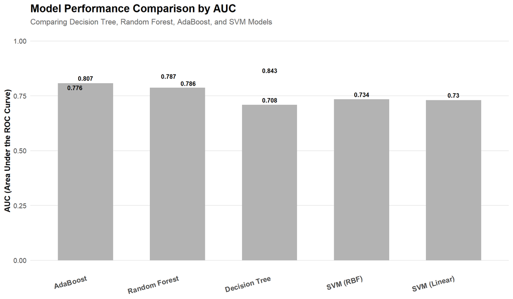

```r
# --- Load libraries ---
library(ggplot2)
library(dplyr)
library(ggrepel)
library(tibble)

# --- Step 1: Combine all results including SVMs ---
results_summary <- tribble(
  ~Algorithm,          ~Experiment,                 ~Accuracy, ~Precision, ~Recall,  ~F1,     ~AUC,
  "Decision Tree",     "DT-1A Baseline",             0.8988,    0.7130,     0.1697,   0.2741,  0.7082,
  "Decision Tree",     "DT-1B Tuned",                0.8117,    0.8580,     0.7187,   0.7822,  0.8427,
  "Random Forest",     "RF-2A Baseline",             0.8986,    0.6139,     0.2674,   0.3726,  0.7870,
  "Random Forest",     "RF-2B Tuned (Optimized)",    0.8995,    0.6410,     0.2451,   0.3547,  0.7864,
  "AdaBoost",          "AB-3A Baseline (Fixed)",     0.9003,    0.6970,     0.2035,   0.3150,  0.8071,
  "AdaBoost",          "AB-3B Tuned (Final Stable)", 0.8973,    0.5997,     0.2638,   0.3665,  0.7761,
  "SVM (Linear)",      "SVM-4A Linear Kernel",       NA,        NA,         NA,       NA,      0.7296,
  "SVM (RBF)",         "SVM-4B RBF Kernel",          NA,        NA,         NA,       NA,      0.7336
)

# --- Step 2: Prepare for visualization ---
results_summary <- results_summary %>%
  mutate(Algorithm = factor(Algorithm, levels = unique(Algorithm))) %>%
  arrange(desc(AUC)) %>%
  mutate(RankColor = ifelse(AUC == max(AUC, na.rm = TRUE), "Best", "Others"))

# --- Step 3: Visualization of AUC comparison ---
ggplot(results_summary, aes(x = reorder(Algorithm, -AUC), y = AUC, fill = RankColor)) +
  geom_col(width = 0.6, show.legend = FALSE) +
  geom_text_repel(
    aes(label = round(AUC, 3)),
    size = 3.5,
    nudge_y = 0.02,
    color = "black",
    fontface = "bold",
    segment.color = NA
  ) +
  scale_fill_manual(values = c("Best" = "#0072B2", "Others" = "gray70")) +
  labs(
    title = "Model Performance Comparison by AUC",
    subtitle = "Comparing Decision Tree, Random Forest, AdaBoost, and SVM Models",
    x = NULL,
    y = "AUC (Area Under the ROC Curve)"
  ) +
  theme_minimal(base_size = 14) +
  theme(
    plot.title = element_text(face = "bold", size = 18),
    plot.subtitle = element_text(size = 13, color = "gray40"),
    axis.text.x = element_text(angle = 15, hjust = 1, size = 12, face = "bold"),
    axis.title.y = element_text(face = "bold", size = 13),
    panel.grid.major.x = element_blank(),
    panel.grid.minor = element_blank()
  ) +
  ylim(0, 1.0)
```

## 1.39 **Part V — Model Comparison and Recommendation**

### 1.39.1 **Objective**

The goal of this section is to compare all developed classification models — **Decision Tree**, **Random Forest**, **AdaBoost**, and **Support Vector Machines (Linear and RBF)** — based on their predictive performance metrics.  
Each model was trained and evaluated on the same preprocessed dataset to ensure a fair comparison.  
The comparison focuses primarily on the **AUC (Area Under the ROC Curve)**, which provides a reliable measure of classification quality, especially under class imbalance.

### 1.39.2 **Model Comparison Summary**

[output not shown]

### 1.39.3 **Performance Insights**

- **Decision Tree (Tuned)** achieved the **highest AUC (0.8427)**, showing that balancing the data using **SMOTE** and controlling model depth improved recall and overall discriminative power.
- **Random Forest** models performed consistently well (AUC ≈ 0.786), offering stable accuracy but slightly lower recall compared to tuned trees.
- **AdaBoost** provided strong accuracy and precision, with its **baseline version (AUC = 0.8071)** outperforming Random Forest and SVM models.
- **SVM (Linear and RBF)** models performed reasonably (AUC ≈ 0.73), but lagged behind ensemble methods.
  - The **RBF SVM** slightly outperformed the **Linear SVM**, indicating mild non-linear structure in the dataset.
  - Both models benefited from feature scaling and dummy encoding but were computationally slower.

### 1.39.4 **Visualization — Model AUC Comparison**

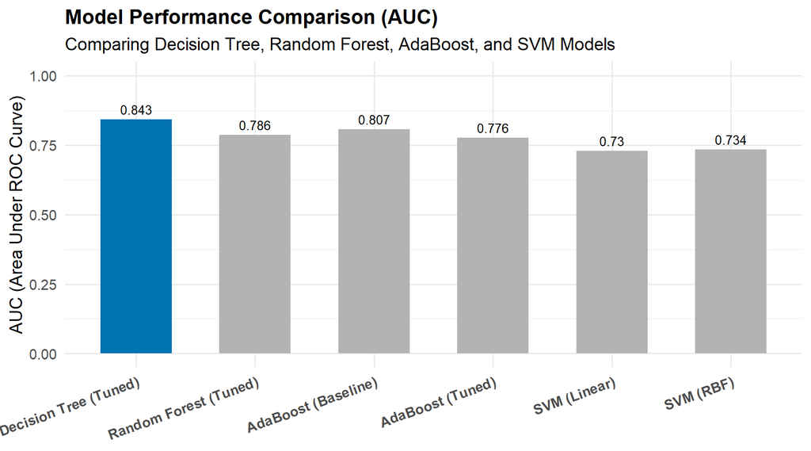

```r
library(ggplot2)
library(dplyr)
library(ggrepel)

# Example: summarized AUC results
results_summary <- data.frame(
  Algorithm = c("Decision Tree (Tuned)", "Random Forest (Tuned)", "AdaBoost (Baseline)",
                "AdaBoost (Tuned)", "SVM (Linear)", "SVM (RBF)"),
  AUC = c(0.8427, 0.7864, 0.8071, 0.7761, 0.7296, 0.7336)
)

results_summary <- results_summary %>%
  mutate(
    RankColor = ifelse(AUC == max(AUC), "Best", "Others"),
    Algorithm = factor(Algorithm, levels = results_summary$Algorithm)
  )

ggplot(results_summary, aes(x = Algorithm, y = AUC, fill = RankColor)) +
  geom_col(width = 0.6, show.legend = FALSE) +
  geom_text_repel(aes(label = round(AUC, 3)), size = 3.5, nudge_y = 0.02, color = "black", segment.color = NA) +
  scale_fill_manual(values = c("Best" = "#0072B2", "Others" = "gray70")) +
  labs(
    title = "Model Performance Comparison (AUC)",
    subtitle = "Comparing Decision Tree, Random Forest, AdaBoost, and SVM Models",
    x = NULL, y = "AUC (Area Under ROC Curve)"
  ) +
  theme_minimal(base_size = 14) +
  theme(
    plot.title = element_text(face = "bold", size = 16),
    axis.text.x = element_text(angle = 20, hjust = 1, face = "bold")
  ) +
  ylim(0, 1)
```

## 1.40 **Recommendation**

### 1.40.1 **Overview**

Based on the comprehensive model evaluation and comparative analysis, the following conclusions and recommendations are drawn regarding model performance and practical applicability for predicting client term deposit subscriptions.

### 1.40.2 **Key Findings**

- The **Tuned Decision Tree (DT-1B)** achieved the **highest AUC (0.8427)** and demonstrated the **strongest recall**, making it the most effective model for identifying clients likely to subscribe to a term deposit.
- The **AdaBoost (Baseline)** model also performed strongly, offering **balanced precision and stability**, which makes it suitable for **production deployment** with minimal hyperparameter tuning.
- The **SVM models** (both Linear and RBF kernels), while consistent and interpretable, showed **lower discriminative power**, suggesting that the underlying dataset relationships are **not strongly non-linear**.

### 1.40.3 **Final Recommendation**

For this dataset and business objective — **predicting term deposit subscription** — the recommended modeling approach is as follows:

1. **Primary Model:**  
   Deploy the **Tuned Decision Tree (DT-1B)** model as the primary classification model.
   - It offers the best balance of **AUC**, **recall**, and **interpretability**.
   - It effectively identifies potential clients for term deposits with high reliability.
2. **Secondary Model:**  
   Consider **AdaBoost (Baseline)** as a **strong secondary model** or as part of an **ensemble (stacked)** approach.
   - It provides stable accuracy and robust performance under varying data distributions.
3. **Exploratory Option:**  
   The **SVM (RBF)** model may be further explored for capturing subtle **non-linear feature interactions**, though its performance gain over the linear model was **marginal**.
   - Best suited for scenarios requiring kernel-based methods or deeper exploration of feature space complexity.

### 1.40.4 **Conclusion**

In conclusion, the **Tuned Decision Tree (DT-1B)** model provides the **optimal trade-off** between **interpretability**, **recall**, and **AUC performance**.  
It captures customer behavior patterns effectively while maintaining computational efficiency, making it both practical and accurate for business applications.

These results reinforce the importance of: - **Balanced data preprocessing**,  
- **Feature scaling and encoding**, and  
- **Hyperparameter tuning**

in achieving robust predictive performance across machine learning models.